# Assignment 9

July 21, 2018

## Contents

- Data
  - Quick EDA
  - Down-Sampling
- Random Forest
  - Modeling
  - Grid-Search
  - Best Model

## Data

## Data - Quick EDA

First, I looked at the summary statistics of credit card data and found two points to adjust.  
1. `Class` variable should be a factor rather than an integer. As such, I changed it to a factor.  
2. `Time` variable is not necessarily needed for this modeling. As such, I removed the entire column.

| V1 | V2 | V3 | V4 | V5 | V6 | V7 | V8 | V9 | V10 | V11 | V12 | V13 | V14 | V15 | V16 | V17 | V18 | V19 | V20 | V21 | V22 | V23 | V24 | V25 | V26 | V27 | V28 | Amount | Class |
| --- | --- | --- | --- | --- | --- | --- | --- | --- | --- | --- | --- | --- | --- | --- | --- | --- | --- | --- | --- | --- | --- | --- | --- | --- | --- | --- | --- | --- | --- |
| -1.3598071 | -0.0727812 | 2.5363467 | 1.3781552 | -0.3383208 | 0.4623878 | 0.2395986 | 0.0986979 | 0.3637870 | 0.0907942 | -0.5515995 | -0.6178009 | -0.9913898 | -0.3111694 | 1.4681770 | -0.4704005 | 0.2079712 | 0.0257906 | 0.4039930 | 0.2514121 | -0.0183068 | 0.2778376 | -0.1104739 | 0.0669281 | 0.1285394 | -0.1891148 | 0.1335584 | -0.0210531 | 149.62 | 0 |
| 1.1918571 | 0.2661507 | 0.1664801 | 0.4481541 | 0.0600176 | -0.0823608 | -0.0788030 | 0.0851017 | -0.2554251 | -0.1669744 | 1.6127267 | 1.0652353 | 0.4890950 | -0.1437723 | 0.6355581 | 0.4639170 | -0.1148047 | -0.1833613 | -0.1457830 | -0.0690831 | -0.2257752 | -0.6386720 | 0.1012880 | -0.3398465 | 0.1671704 | 0.1258945 | -0.0089831 | 0.0147242 | 2.69 | 0 |
| -1.3583541 | -1.3401631 | 1.7732093 | 0.3797796 | -0.5031981 | 1.8004994 | 0.7914610 | 0.2476758 | -1.5146543 | 0.2076429 | 0.6245015 | 0.0660837 | 0.7172927 | -0.1659459 | 2.3458649 | -2.8900832 | 1.1099694 | -0.1213593 | -2.2618571 | 0.5249797 | 0.2479982 | 0.7716794 | 0.9094123 | -0.6892810 | -0.3276418 | -0.1390966 | -0.0553528 | -0.0597518 | 378.66 | 0 |
| -0.9662717 | -0.1852260 | 1.7929933 | -0.8632913 | -0.0103089 | 1.2472032 | 0.2376089 | 0.3774359 | -1.3870241 | -0.0549519 | -0.2264873 | 0.1782282 | 0.5077569 | -0.2879237 | -0.6314181 | -1.0596472 | -0.6840928 | 1.9657750 | -1.2326220 | -0.2080378 | -0.1083005 | 0.0052736 | -0.1903205 | -1.1755753 | 0.6473760 | -0.2219288 | 0.0627228 | 0.0614576 | 123.50 | 0 |
| -1.1582331 | 0.8777368 | 1.5487178 | 0.4030339 | -0.4071934 | 0.0959215 | 0.5929407 | -0.2705327 | 0.8177393 | 0.7530744 | -0.8228429 | 0.5381956 | 1.3458516 | -1.1196698 | 0.1751211 | -0.4514492 | -0.2370332 | -0.0381948 | 0.8034869 | 0.4085424 | -0.0094307 | 0.7982785 | -0.1374581 | 0.1412670 | -0.2060096 | 0.5022922 | 0.2194222 | 0.2151531 | 69.99 | 0 |
| -0.4259659 | 0.9605230 | 1.1411093 | -0.1682521 | 0.4209869 | -0.0297276 | 0.4762009 | 0.2603143 | -0.5686714 | -0.3714072 | 1.3412620 | 0.3598938 | -0.3580907 | -0.1371337 | 0.5176168 | 0.4017259 | -0.0581328 | 0.0686531 | -0.0331938 | 0.0849677 | -0.2082535 | -0.5598248 | -0.0263977 | -0.3714266 | -0.2327938 | 0.1059148 | 0.2538442 | 0.0810803 | 3.67 | 0 |

## Data - Down-Sampling

As we can see from the below table, we have an extremely unbalanced data.  
When we look at a table of `Class` variable, fraud class(\(1\)) take only \(0.173\)%.  
Therefore,  
1. We need to do down-sampling to balance the imbalanced dataset.  
2. We need to come up with the right evaluation metrics later on.

```
##
##      0      1
## 284315    492
```

## Data - Down-Sampling

Since the \(1\) class has around \(492\) observations, I sampled \(5000\) cases from `Class == 0`.

```
##
##    0    1
## 5000  492
```

## Random Forest

## RF - Modeling

After initializing the h2o,  
1. I changed the dataset into h2o data frame format,  
2. split the dataset into `train`, `valid`, and `test` set, and  
3. set the response and predictive variables respectively.

## RF - Modeling

Then, I built a random forest model, using `h2o.randomForest`.  
Each hyper-parameter represents as follows. [(source)](https://www.kaggle.com/mlandry/random-forest-example)

1. `ntrees`: It determines the number of trees to grow.
2. `max_depth`: It determines the maximum depth to grow the tree. The bigger, the smaller number of classes will be assigned in the leaf nodes.
3. `mtries`: It selects the number of variables that would be sampled as candidate at each node split.
4. `min_rows`: It determines the number of rows to assign to terminal nodes.

## RF - Modeling

After fitting the model, I looked at the performance metrics as follows.

```
## [1] "MSE: 0.01495, RMSE: 0.12226, LogLoss: 0.11745"
```

```
## [1] "AUC: 0.97653, Gini: 0.95305"
```

## RF - Grid-Search

To find the best combination of hyper-parameters, I am going to conduct grid-search.  
For this assignment, I tried different ranges from three parameters: `ntrees`, `max_depth`, and `mtries`.

## RF - Grid-Search

After doing the grid search, I sorted the model by descending order of AUC, to find the best model to use.

```
## Hyper-Parameter Search Summary: ordered by decreasing auc
##   max_depth mtries ntrees         model_ids                auc
## 1        10     12    700  rf_grid_model_85 0.9682400429774712
## 2        10     12    500  rf_grid_model_60 0.9682400429774712
## 3        10     12    900 rf_grid_model_110 0.9682400429774712
## 4        10     12    300  rf_grid_model_35 0.9682400429774712
## 5        10     12    100  rf_grid_model_10 0.9679196833861516
##
## ---
##     max_depth mtries ntrees        model_ids                auc
## 120        25      4    500 rf_grid_model_53 0.9518844536883245
## 121        25      4    700 rf_grid_model_78 0.9518844536883245
## 122        20     20    100 rf_grid_model_22  0.950391085131865
## 123        25     20    100 rf_grid_model_23  0.950391085131865
## 124        30     20    100 rf_grid_model_24  0.950391085131865
## 125        15     20    100 rf_grid_model_21 0.9499277958767256
```

## RF - Best Model

I set the best model as the one with the highest AUC from the grid-search result.  
I printed the variable importances, the number of trees, and the maximum depth of the tree, used in my best model.

```
## [1] "The top 5 important variables: V14 V17 V10 V12 V11"
```

```
## [1] "In my best model, the number of trees is 160, "
```

```
## [1] "and maximum depth of the tree is 10"
```

## RF - Best Model

In addition, I plotted `Training RMSE` and `Validation RMSE` along with the number of trees as follows.

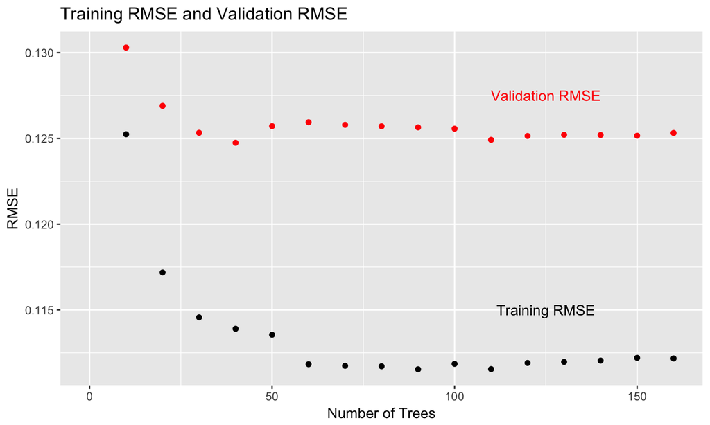

## RF - Best Model

Finally, I tested on my `test` data to compare with the first random forest result, which I selected random hyperparameters.  
As we can see from the below result, we can find that overall results are improved.  
(For instance, `AUC` is improved from around 97% to 98%.)

```
## [1] "MSE: 0.01382, RMSE: 0.11757, LogLoss: 0.06202"
```

```
## [1] "AUC: 0.97808, Gini: 0.95616"
```

## RF - Best Model

To conclude, I plotted both `ROC` and `Precision-Recall` curve.  
1. `ROC`: As we can see from the above plot, it is pretty much close to the top-left corner (Our AUC is around 0.98).

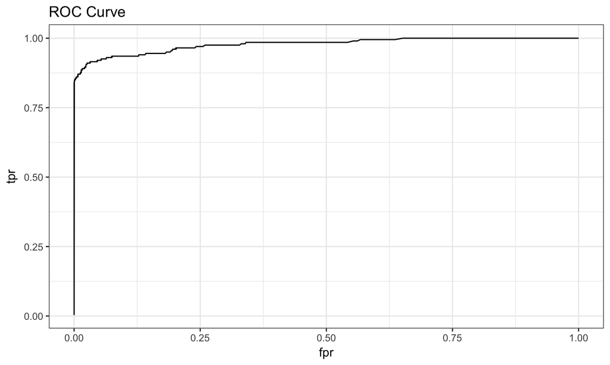

## RF - Best Model

2. `Precision-Recall`: I believe that since we have a quite imbalanced dataset, we better to look at the precision-recall curve since precision is directly influenced by class imbalance. Still, we can find that the graph is pretty much close to the upper-right corner, which is our optimum.

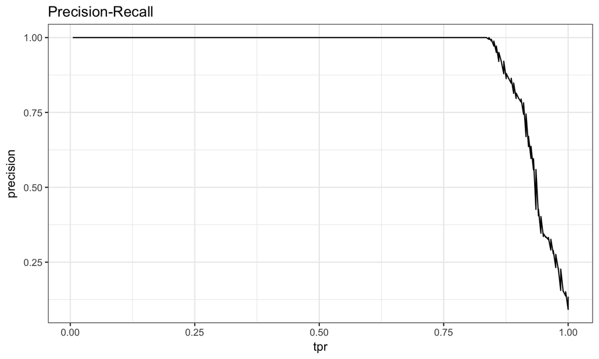